# Coherent multi-disease, multi-stratum mortality projection (Japan)

bamp

```r
library(bamp)
```

## The problem

Projecting mortality for several diseases, by sex, the *independent* way — one model per disease, one model per sex — has two well-known failures:

1. **Incoherence across diseases.** Independently projected cause-specific rates do not add up to a sensible all-cause trajectory, and the dependence between causes (cardiovascular causes tend to rise and fall *together*) is ignored.
2. **Divergence across strata.** Independent sex-specific forecasts drift apart without bound, producing implausible male/female gaps at long horizons.

This vignette uses Japanese mortality (1995–2019, ages 30–80+) for **CHD**, **stroke** and **all other (“non-modelled”) causes** — three competing causes that partition all deaths (`non-modelled = total − CHD − stroke`) — to show the **recommended** coherent approach and contrast it with independent projections. We project to **2050** using the official population projections as future denominators.

```r
## ---- load the bundled Japan data, ages 30-80+, [year x agegroup] ----
jdir <- system.file("extdata", "japan", package = "bamp")
if (jdir == "" || !dir.exists(jdir)) jdir <- "../inst/extdata/japan"   # source tree (build time)
age10 <- c("age30_34","age35_39","age40_44","age45_49","age50_54","age55_59",
           "age60_64","age65_69","age70_74","age75_79")
age80p <- c("age80_84","age85_89","age90_94","age95_99","age100_")
read_death <- function(f) {
  d <- read.csv(file.path(jdir, f), check.names = FALSE)
  M <- cbind(as.matrix(d[, age10]), "80+" = rowSums(d[, age80p]))      # collapse 80+ to match pop
  rownames(M) <- d[["year"]]; M
}
pop_mat <- function(sx) {
  p <- read.csv(file.path(jdir, "population_per_5yo.csv"))
  m <- xtabs(pops ~ Year + age, data = p[p$sex == sx & p$age %in% seq(30, 80, 5), ])
  matrix(as.double(m), nrow(m), ncol(m), dimnames = dimnames(m))
}
load_sex <- function(sx, fit = 1995:2019, to = 2050) {
  yr <- as.character(fit)
  chd <- read_death(sprintf("chd_%s.csv", sx))[yr, ]
  str <- read_death(sprintf("stroke_%s.csv", sx))[yr, ]
  oth <- read_death(sprintf("nonmodeled_%s.csv", sx))[yr, ]
  pop <- pop_mat(sx)
  list(CHD = chd, stroke = str, other = oth, total = chd + str + oth,
       pop = pop[yr, ], pop_fut = pop[as.character(min(fit):to), ])
}
men   <- load_sex("men")
women <- load_sex("women")
ages  <- c("30-34","35-39","40-44","45-49","50-54","55-59","60-64","65-69","70-74","75-79","80+")
years <- 1995:2050; A <- 9   # focus age band 70-74
cat(sprintf("grid: %d age groups x %d fitted years (1995-2019), projected to 2050\n",
            length(ages), nrow(men$total)))
```

```
#> grid: 11 age groups x 25 fitted years (1995-2019), projected to 2050
```

## Part A — competing diseases, coherently (men)

The recommended model for several competing causes is `bamp_multicause()`. It stick-breaks the deaths into cause-specific shares, so the cause rates **sum to all-cause by construction**, and it couples the cause *trends* through a cross-cause covariance, so it learns whether causes move together. Cause-specific **hazards** (additive, per person-year) are what a competing-risk life-table / microsimulation needs.

```r
fit_mc <- bamp_multicause(list(CHD = men$CHD, stroke = men$stroke, other = men$other),
                          men$pop, age = "rw1", period = "rw1", cohort = "rw1",
                          periods_per_agegroup = 5, order = 1:3, mcmc = mco)
pmc <- predict_multicause(fit_mc, periods = 31, population = men$pop_fut,
                          hazard = TRUE, period_length = 1)
```

### Cause-specific projections (and they stay coherent)

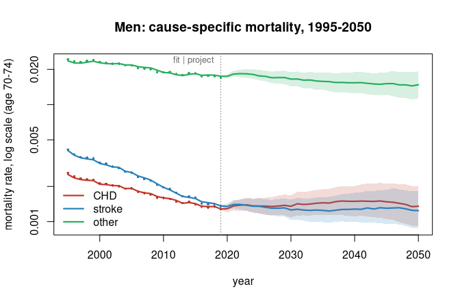

```r
cols <- c(CHD = "#c0392b", stroke = "#2980b9", other = "#27ae60")
yl <- range(unlist(lapply(names(cols), function(nm) pmc[[nm]]$rate[c(1, 3), , A])))
plot(NA, xlim = c(1995, 2050), ylim = yl, log = "y", xlab = "year",
     ylab = "mortality rate, log scale (age 70-74)",
     main = "Men: cause-specific mortality, 1995-2050")
abline(v = 2019, lty = 3, col = "grey50")
for (nm in names(cols)) {
  band(years, pmc[[nm]]$rate[, , A], cols[nm], add = TRUE)
  points(1995:2019, men[[nm]][, A] / men$pop[, A], pch = 16, cex = 0.5, col = cols[nm])
}
legend("bottomleft", names(cols), col = cols, lwd = 2.2, bty = "n")
text(2019, yl[2], "fit | project", pos = 2, cex = 0.8, col = "grey40")
```

CHD and stroke both decline; “other” causes dominate and flatten. Dots are the observed rates. Because the model is coherent, the three cause rates **add up to the all-cause rate every draw**:

```r
cat("max |sum of cause rates - all-cause| over the whole grid:", signif(pmc$coherence_maxerr, 3), "\n")
```

```
#> max |sum of cause rates - all-cause| over the whole grid: 2.78e-17
```

### What independent cause models miss #1: coherence with all-cause

If instead we fit each cause *independently* and add the projected rates, the sum drifts away from a direct all-cause projection — there is no guarantee the parts add to the whole.

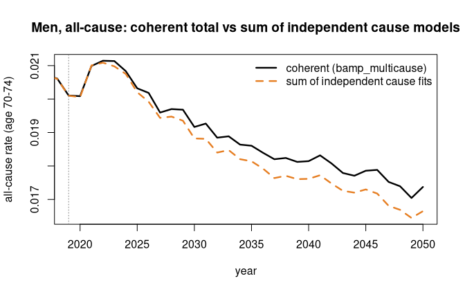

```r
fit_ind <- lapply(c("CHD", "stroke", "other"), function(nm)
  bamp(men[[nm]], men$pop, age = "rw1", period = "rw1", cohort = "rw1",
       periods_per_agegroup = 5, mcmc.options = bo, parallel = FALSE, verbose = FALSE))
pr_ind <- lapply(fit_ind, predict_apc, periods = 31, population = men$pop_fut)
sum_ind <- Reduce(`+`, lapply(pr_ind, function(p) p$pr[2, , A]))      # sum of independent medians
futA <- years >= 2019
plot(years, pmc$total$rate[2, , A], type = "l", lwd = 2.4, col = "black",
     xlim = c(2019, 2050), ylim = range(c(pmc$total$rate[2, futA, A], sum_ind[futA])),
     xlab = "year", ylab = "all-cause rate (age 70-74)",
     main = "Men, all-cause: coherent total vs sum of independent cause models")
lines(years, sum_ind, lwd = 2.4, col = "#e67e22", lty = 2)
abline(v = 2019, lty = 3, col = "grey50")
legend("topright", c("coherent (bamp_multicause)", "sum of independent cause fits"),
       col = c("black", "#e67e22"), lwd = 2.4, lty = c(1, 2), bty = "n")
```

The orange “sum of independent fits” peels away from the coherent all-cause projection — the incoherence grows with horizon. The coherent model cannot do this: its causes are shares of the all-cause total.

### What independent cause models miss #2: cross-cause dependence

The coupled model estimates how the cause trends move together (the cross-cause correlation of the period innovations). Independent models implicitly assume this is **zero**.

```r
round(pmc$cor_omega, 2)
```

```
#>         CHD stroke
#> CHD    1.00   0.72
#> stroke 0.72   1.00
```

CHD and stroke are strongly **positively** correlated — in Japan both cardiovascular causes declined together (shared risk-factor improvements). A coupled model propagates that joint movement into the forecast; independent models treat the causes as unrelated, mis-stating the joint uncertainty (e.g. of total cardiovascular mortality).

## Part B — coherence across sex

For strata (here sex) the recommended model is `bamp_coherent()`: the sexes share the period and cohort trends and differ by a *mean-reverting* deviation, so the male/female gap cannot diverge. We compare it with two independent `bamp` fits on total (30+) mortality.

```r
fc <- bamp_coherent(list(men = men$total, women = women$total),
                    list(men = men$pop,  women = women$pop),
                    age = "rw1", period = "rw1", cohort = "rw1",
                    periods_per_agegroup = 5, deviation = "ar1", mcmc = mco)
pc <- predict_coherent(fc, periods = 31, population = list(men = men$pop_fut, women = women$pop_fut))

fm <- bamp(men$total,   men$pop,   age = "rw1", period = "rw1", cohort = "rw1",
           periods_per_agegroup = 5, mcmc.options = bo, parallel = FALSE, verbose = FALSE)
fw <- bamp(women$total, women$pop, age = "rw1", period = "rw1", cohort = "rw1",
           periods_per_agegroup = 5, mcmc.options = bo, parallel = FALSE, verbose = FALSE)
pm <- predict_apc(fm, periods = 31, population = men$pop_fut)
pw <- predict_apc(fw, periods = 31, population = women$pop_fut)
```

### Projected male/female mortality

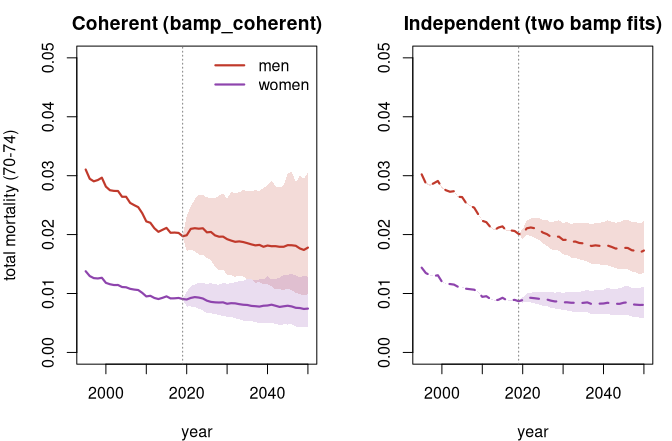

```r
par(mfrow = c(1, 2), mar = c(4, 4, 2.4, 1))
yl <- c(0, 0.05)
plot(NA, xlim = c(1995, 2050), ylim = yl, xlab = "year", ylab = "total mortality (70-74)",
     main = "Coherent (bamp_coherent)")
band(years, pc$men$rate[, , A],   "#c0392b", add = TRUE)
band(years, pc$women$rate[, , A], "#8e44ad", add = TRUE)
abline(v = 2019, lty = 3, col = "grey50"); legend("topright", c("men","women"),
       col = c("#c0392b","#8e44ad"), lwd = 2.2, bty = "n")
plot(NA, xlim = c(1995, 2050), ylim = yl, xlab = "year", ylab = "",
     main = "Independent (two bamp fits)")
band(years, pm$pr[, , A], "#c0392b", add = TRUE, lty = 2)
band(years, pw$pr[, , A], "#8e44ad", add = TRUE, lty = 2)
abline(v = 2019, lty = 3, col = "grey50")
```

```r
par(mfrow = c(1, 1))
```

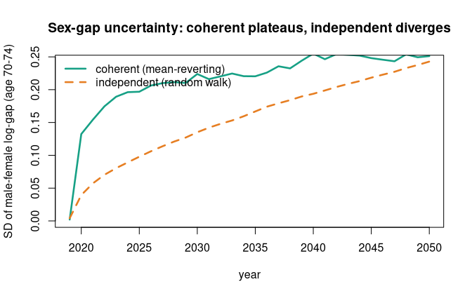

```r
gap_sd <- function(rm, rw) vapply(seq_along(years),
  function(t) sd(log(rm[t, A, ]) - log(rw[t, A, ])), 0.0)
sd_coh <- gap_sd(pc$men$samples$rate, pc$women$samples$rate)
sd_ind <- gap_sd(pm$samples$pr,        pw$samples$pr)
fut <- years >= 2019
plot(years[fut], sd_coh[fut], type = "l", lwd = 2.6, col = "#16a085", ylim = c(0, max(sd_ind[fut])),
     xlab = "year", ylab = "SD of male-female log-gap (age 70-74)",
     main = "Sex-gap uncertainty: coherent plateaus, independent diverges")
lines(years[fut], sd_ind[fut], lwd = 2.6, col = "#e67e22", lty = 2)
legend("topleft", c("coherent (mean-reverting)", "independent (random walk)"),
       col = c("#16a085", "#e67e22"), lwd = 2.6, lty = c(1, 2), bty = "n")
```

```r
gap_mean <- function(rm, rw, t) mean(log(rm[t, A, ]) - log(rw[t, A, ]))
cat(sprintf("mean male-female log-gap (70-74)  2020 -> 2050:  coherent %.2f -> %.2f | independent %.2f -> %.2f\n",
            gap_mean(pc$men$samples$rate, pc$women$samples$rate, 26),
            gap_mean(pc$men$samples$rate, pc$women$samples$rate, 56),
            gap_mean(pm$samples$pr, pw$samples$pr, 26),
            gap_mean(pm$samples$pr, pw$samples$pr, 56)))
```

```
#> mean male-female log-gap (70-74)  2020 -> 2050:  coherent 0.80 -> 0.84 | independent 0.81 -> 0.76
```

## Part C — both at once: causes *within* coherent sexes

The two ideas **compose by layering**: take the sex-coherent all-cause total from Part B and split each sex’s total into causes using the cause shares from Part A (fit per sex). The result is a hazard tensor `[age x year x sex x cause]` that is coherent on **both** margins — the causes sum to each sex’s total (cause coherence) *and* the sex totals do not diverge (sex coherence) — while carrying the cross-cause dependence. This is exactly the object a competing-risk microsimulation needs.

```r
## women's competing-cause model (men's `fit_mc` is from Part A)
fit_mc_w <- bamp_multicause(list(CHD = women$CHD, stroke = women$stroke, other = women$other),
                            women$pop, age = "rw1", period = "rw1", cohort = "rw1",
                            periods_per_agegroup = 5, order = 1:3, mcmc = mco)
pmc_w <- predict_multicause(fit_mc_w, periods = 31, population = women$pop_fut,
                            hazard = TRUE, period_length = 1)

## layer: cause rate = sex-coherent total (Part B)  x  cause share within sex (Part A)
layer_cause <- function(pc_sex, pmc_sex, nm) {
  D <- min(dim(pc_sex$samples$rate)[3], dim(pmc_sex$total$samples$rate)[3])
  sh <- pmc_sex[[nm]]$samples$rate[, , seq_len(D)] / pmc_sex$total$samples$rate[, , seq_len(D)]
  sh[!is.finite(sh)] <- 0
  apply(pc_sex$samples$rate[, , seq_len(D)] * sh, 1:2, median)     # [period, age] layered median rate
}
lay <- list(
  men   = sapply(c("CHD","stroke","other"), function(nm) layer_cause(pc$men,   pmc,   nm)[, A]),
  women = sapply(c("CHD","stroke","other"), function(nm) layer_cause(pc$women, pmc_w, nm)[, A]))
```

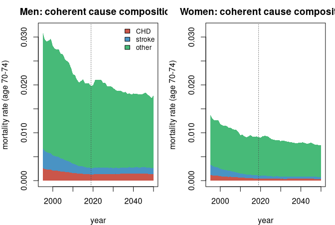

```r
scol <- adjustcolor(c("#c0392b", "#2980b9", "#27ae60"), 0.85)
stack_area <- function(M, main, ymax) {            # M: [period x cause] medians
  cum <- t(apply(M, 1, cumsum))
  plot(NA, xlim = c(1995, 2050), ylim = c(0, ymax), xlab = "year",
       ylab = "mortality rate (age 70-74)", main = main)
  prev <- rep(0, nrow(M))
  for (k in seq_len(ncol(M))) {
    polygon(c(years, rev(years)), c(prev, rev(cum[, k])), col = scol[k], border = NA); prev <- cum[, k] }
  abline(v = 2019, lty = 3, col = "grey30")
}
ymax <- max(rowSums(lay$men), rowSums(lay$women)) * 1.02
par(mfrow = c(1, 2), mar = c(4, 4, 2.4, 1))
stack_area(lay$men,   "Men: coherent cause composition",   ymax)
legend("topright", c("CHD","stroke","other"), fill = scol, bty = "n", cex = 0.85)
stack_area(lay$women, "Women: coherent cause composition", ymax)
```

```r
par(mfrow = c(1, 1))
```

Each panel’s **total height is the sex-coherent all-cause rate** (so the men’s and women’s stacks stay plausibly related into 2050, inheriting the non-divergence of Part B), and the coloured bands are the **cause-coherent decomposition** (they sum to that height by construction). Six fully-independent (cause × sex) models would give neither guarantee — the bands would not sum to a sensible total and the male/female totals would drift apart. The layered hazards sum to the sex-coherent total **exactly, every posterior draw** (the cause shares sum to 1 by construction):

```r
sum_layered <- function(pc_sex, pmc_sex) {
  D <- min(dim(pc_sex$samples$rate)[3], dim(pmc_sex$total$samples$rate)[3])
  s <- Reduce(`+`, lapply(c("CHD","stroke","other"), function(nm) {
    sh <- pmc_sex[[nm]]$samples$rate[, , seq_len(D)] / pmc_sex$total$samples$rate[, , seq_len(D)]
    sh[!is.finite(sh)] <- 0
    pc_sex$samples$rate[, , seq_len(D)] * sh }))
  max(abs(s - pc_sex$samples$rate[, , seq_len(D)]))
}
cat("per-draw max |sum of layered cause rates - sex-coherent total|  (men, women):",
    signif(c(sum_layered(pc$men, pmc), sum_layered(pc$women, pmc_w)), 2), "\n")
```

```
#> per-draw max |sum of layered cause rates - sex-coherent total|  (men, women): 2.8e-17 2.8e-17
```

## Part D — the whole thing in one call

Parts A–C built the tensor by hand. `bamp_sex_cascade()` does it in a single call for a disease **taxonomy**: it fits the sex-coherent all-cause total (Part B) and a disease cascade within each sex (Part A, nested by group), and `predict_sex_cascade()` layers them. The result is the full `[year × age × sex × group × disease]` coherent hazard tensor an NCD microsimulation consumes — here with a CVD group (CHD + stroke) and the residual “other”.

```r
taxonomy <- list(CVD = c("CHD", "stroke"), other = "other")
casc <- bamp_sex_cascade(
  taxonomy,
  cases = list(men   = list(CHD = men$CHD,   stroke = men$stroke,   other = men$other),
               women = list(CHD = women$CHD, stroke = women$stroke, other = women$other)),
  population = list(men = men$pop, women = women$pop),
  periods_per_agegroup = 5, deviation = "ar1",
  mcmc_total = mco, mcmc_cascade = mco)
ten <- predict_sex_cascade(casc, periods = 31, hazard = TRUE, period_length = 1,
                           population = list(men = men$pop_fut, women = women$pop_fut))
str(ten$men$CHD$samples$hazard)                    # [year, age, draw] for one (sex, disease) cell
```

```
#>  num [1:56, 1:11, 1:500] 3.40e-05 3.26e-05 3.32e-05 3.42e-05 3.23e-05 ...
#>  - attr(*, "dimnames")=List of 3
#>   ..$ : NULL
#>   ..$ : NULL
#>   ..$ : NULL
```

It is coherent on **every** margin at once — diseases sum to their group, groups to each sex’s all-cause, and the sex totals stay sex-coherent:

```r
cat("diseases -> sex total (machine exact):", signif(ten$coherence_maxerr, 2), "\n")
```

```
#> diseases -> sex total (machine exact): 2.8e-17
```

```r
cat("CHD + stroke == CVD group (men):",
    signif(max(abs(ten$men$CHD$samples$rate + ten$men$stroke$samples$rate -
                   ten$men$groups$CVD$samples$rate)), 2), "\n")
```

```
#> CHD + stroke == CVD group (men): 1e-17
```

```r
hz <- Reduce(`+`, lapply(ten$leaves, function(l) ten$women[[l]]$samples$hazard))
cat("leaf hazards -> women all-cause hazard:", signif(max(abs(hz - ten$women$total$samples$hazard)), 2), "\n")
```

```
#> leaf hazards -> women all-cause hazard: 2.8e-17
```

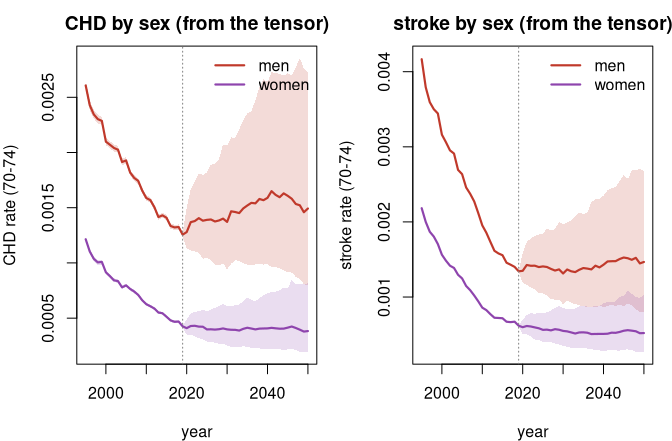

```r
## one disease (CHD) by sex straight from the tensor -- the sexes stay coherent (non-diverging)
par(mfrow = c(1, 2), mar = c(4, 4, 2.4, 1))
for (dis in c("CHD", "stroke")) {
  yl <- range(ten$men[[dis]]$rate[c(1, 3), , A], ten$women[[dis]]$rate[c(1, 3), , A])
  plot(NA, xlim = c(1995, 2050), ylim = yl, xlab = "year",
       ylab = paste(dis, "rate (70-74)"), main = paste(dis, "by sex (from the tensor)"))
  band(years, ten$men[[dis]]$rate[, , A],   "#c0392b", add = TRUE)
  band(years, ten$women[[dis]]$rate[, , A], "#8e44ad", add = TRUE)
  abline(v = 2019, lty = 3, col = "grey50")
  legend("topright", c("men", "women"), col = c("#c0392b", "#8e44ad"), lwd = 2.2, bty = "n")
}
```

```r
par(mfrow = c(1, 1))
```

Each disease’s male/female projection inherits the non-divergence of the all-cause total, the diseases sum coherently within each sex, and the cross-cause and cross-sex dependence are all carried through — in one call. For dozens of diseases, group them in the taxonomy (each level stays a small fit) and add `factor = R` for cross-cutting, risk-factor-driven coupling across groups.

## Recommended workflow

- **Diseases that compete** → `bamp_multicause()` (cause shares sum to all-cause; cross-cause trends coupled; emit additive per-person-year hazards for a microsimulation).
- **Exhaustive strata (sex, education, …)** → `bamp_coherent()` (shared trend + mean-reverting deviation; the between-stratum gap cannot diverge). `S > 2` strata are supported.
- **Many diseases** → `bamp_cascade()` (a disease taxonomy as nested small fits; add `factor = R` for cross-cutting, risk-factor-driven coupling across groups).
- **Both at once** → `bamp_sex_cascade()` / `predict_sex_cascade()` (Part D): one call for the full `[year × age × sex × group × disease]` coherent tensor. See `docs/coherent-forecasting.md` for the nested cascade and the out-of-sample validation harness (`coherence_backtest()`, `select_rho()`).

The advantage over independent projection is not mainly short-horizon accuracy (the methods are comparable there) but **coherence** — the parts add to the whole, the causes move together as the data say, and the strata stay plausibly related — which is exactly what long-range, multi-disease, multi-stratum projection needs. ```